# BondPrice

## 債券取價流程及利率風險分析

本專案旨在模擬銀行債券投資部位，並依據公開資訊自動化取價流程，進行持倉市價更新與利率風險分析。

### 方法設計

1.資料抓取與清理

- 每日自動下載交易所公布的最新價格資料
- 依取價邏輯（成交優先於理論價）對應至持有的position

2.百元價更新

- 依債券代號（BondID）配對市價與殖利率，回填至模擬的position檔案。
- 計算持倉 MTM（Mark-to-Market）盈虧，並延伸計算 DVO1（利率敏感度）。

3.風險分析

- 比較不同債券類型（公司債、公債、金融債）的 MTM 分布與 DV01 敏感度。
- 使用 DVO1_per_Position 與非參數檢定（Kruskal-Wallis test）探討持倉配置效應與Duration效應。

## 債券的取價邏輯

1.當日有成交價採用當日成交價

2.當日無成交行情，採用一個月內成交價

3.一個月內無成交行情，採用OTC理論價

```python
import os
import requests
import pandas as pd
import scipy.stats as stats
from datetime import datetime, timedelta
from IPython.display import display, HTML
```

首先，用程式碼自動到OTC網站抓取今日的券商報價

- 等殖成交行情表
- 處所成交各期次債券殖利率及百元價格表
- 一個月成交行情
- 公債理論價
- 公司債及金融債理論價

資料來源： [Taipei Exchange](https://www.tpex.org.tw/zh-tw/index.html)

```python
SAVE_DIR = "bond_data"
os.makedirs(SAVE_DIR, exist_ok=True)

# 今天日期
today = datetime.today()
YYYY = today.strftime("%Y")
YYYYMM = today.strftime("%Y%m")
YYYYMMDD = today.strftime("%Y%m%d")
# 每日的檔案連結（4份）
urls = {
    "等殖成交": f"https://www.tpex.org.tw/storage/bond_zone/tradeinfo/govbond/{YYYY}/{YYYYMM}/BDdys01a.{YYYYMMDD}-C.xls",
    "處所成交": f"https://www.tpex.org.tw/storage/bond_zone/tradeinfo/govbond/{YYYY}/{YYYYMM}/BDdcs020.{YYYYMMDD}-C.xls",
    "公債理論價": f"https://www.tpex.org.tw/storage/bond_zone/tradeinfo/govbond/{YYYY}/{YYYYMM}/BDdys503.{YYYYMMDD}-C.xls",
    "公司債金融債理論價": f"https://www.tpex.org.tw/storage/bloomberg/bndcrvpx_{YYYYMMDD}.csv"
}

def download_file(url, save_path):
    """下載單一檔案"""
    try:
        r = requests.get(url, timeout=10)
        if r.status_code == 200:
            with open(save_path, "wb") as f:
                f.write(r.content)
            print(f"成功下載: {save_path}")
        else:
            print(f"檔案不存在: {url}")
    except Exception as e:
        print(f"錯誤: {url} - {e}")

# 下載每日檔案
for name, url in urls.items():
    ext = url.split(".")[-1]
    save_path = os.path.join(SAVE_DIR, f"{name}_{YYYYMMDD}.{ext}")
    download_file(url, save_path)

# 特殊處理：一個月內成交價 → 永遠抓「上個月」
last_month = (today.replace(day=1) - timedelta(days=1)).replace(day=1)
YYYY_last = last_month.strftime("%Y")
YYYYMM_last = last_month.strftime("%Y%m")
MM_last = last_month.strftime("%m")

url_month = f"https://www.tpex.org.tw/storage/bond_zone/tradeinfo/govbond/{YYYY_last}/BDmys0{MM_last}.{YYYYMM_last}-C.xls"
save_path_month = os.path.join(SAVE_DIR, f"一個月內成交價_{YYYYMM_last}.xls")

download_file(url_month, save_path_month)
```

```
成功下載: bond_data/等殖成交_20250916.xls
成功下載: bond_data/處所成交_20250916.xls
成功下載: bond_data/公債理論價_20250916.xls
成功下載: bond_data/公司債金融債理論價_20250916.csv
成功下載: bond_data/一個月內成交價_202508.xls
```

### 整理並mapping檔案欄位

BondPosition是我們所持有的債券基本資料，包含BondID、BondName、BondType、MarketPrice、Yield等欄位

我們要從今天的報價中，依照取價邏輯為我們現有的債券部位取價（更新現有檔案的MarketPrice及Yield），並加入取價來源，這樣能更清楚bond在市場上的成交情形。

因為5個檔案需要用到的欄位都不同，我們要從5個檔案中各別找到我們所持有的Bond的百元報價以及殖利率

```python
bond_file = "/Users/kpwei/Documents/pytest/bond_data/BondPosition.xlsx"
bond_pos = pd.read_excel(bond_file, engine="openpyxl")

file_mappings = {
    f"/Users/kpwei/Documents/pytest/bond_data/等殖成交_{YYYYMMDD}.xls": {
        "BondID": "A", "Yield": "L", "Price": "G", "Source": "等殖", "type": "xls"
    },
    f"/Users/kpwei/Documents/pytest/bond_data/處所成交_{YYYYMMDD}.xls": {
        "BondID": "A", "Yield": "H", "Price": "I", "Source": "處所", "type": "xls"
    },
    f"/Users/kpwei/Documents/pytest/bond_data/一個月內成交價_{YYYYMM_last}.xls": {
        "BondID": "A", "Yield": "G", "Price": "H", "Source": "一個月", "type": "xls"
    },
    f"/Users/kpwei/Documents/pytest/bond_data/公債理論價_{YYYYMMDD}.xls": {
        "BondID": "A", "Yield": "N", "Price": "O", "Source": "理論價", "type": "xls"
    },
    f"/Users/kpwei/Documents/pytest/bond_data/公司債金融債理論價_{YYYYMMDD}.csv": {
        "BondID": "A", "Yield": "G", "Price": "F", "Source": "理論價", "type": "csv"
    },
}
```

### 訂定取價優先順序

**等殖成交→處所成交→一個月內成交→理論價**

在讀「處所成交」檔案時，只保留「最近成交日」等於今天日期的債券資料，因為處所檔案可能有很多舊資料，不篩會誤用

且處理「處所成交」時印出有幾筆符合當天日期的資料，方便確認

```python
class BondDataLoader:
    def __init__(self, file_mappings: dict, roc_date: str, priority: dict = None):
        """
        file_mappings: dict, 每個檔案的欄位設定，例如
            {
                "處所成交.xlsx": {"BondID": "A", "Yield": "B", "Price": "C", "Source": "處所", "type": "xlsx"},
                "等殖.xls": {"BondID": "D", "Yield": "E", "Price": "F", "Source": "等殖", "type": "xls"},
            }
        roc_date: str, 交易日期 (民國格式字串)
        priority: dict, (可選) 資料來源優先順序
        """
        self.file_mappings = file_mappings
        self.roc_date = roc_date
        self.priority = priority if priority else {}
        self.all_data = pd.DataFrame()

    def _col_to_index(self, col: str) -> int:
        """將 Excel 欄位字母轉成 index (A=0, B=1, ...)"""
        return ord(col.upper()) - ord("A")

    def _read_file(self, file: str, file_type: str):
        """依照副檔名讀取檔案"""
        if file_type == "xlsx":
            return pd.read_excel(file, engine="openpyxl", header=None)
        elif file_type == "xls":
            return pd.read_excel(file, engine="xlrd", header=None)
        elif file_type == "csv":
            return pd.read_csv(file, encoding="cp950", header=None)
        else:
            raise ValueError(f"Unknown file type for {file}")

    def _process_file(self, file: str, cols: dict):
        """處理單一檔案"""
        # 建立欄位對應
        col_map = {name: self._col_to_index(col)
                   for name, col in cols.items() if name not in ["Source", "type"]}

        # 讀取檔案
        df = self._read_file(file, cols["type"])

        # 特別處理「處所成交」檔案
        if cols["Source"] == "處所":
            date_col = self._col_to_index("J")  # J 欄
            df = df[df.iloc[:, date_col].astype(str).str.strip() == self.roc_date]
            print(f"處所成交：共 {len(df)} 筆符合 {self.roc_date} 的資料")

        # 萃取需要欄位
        temp = df.iloc[:, [col_map["BondID"], col_map["Yield"], col_map["Price"]]].copy()
        temp.columns = ["BondID", "Yield", "MarketPrice"]
        temp["Source"] = cols["Source"]

        return temp

    def load_all(self):
        """讀取所有檔案並合併"""
        for file, cols in self.file_mappings.items():
            temp = self._process_file(file, cols)
            self.all_data = pd.concat([self.all_data, temp], ignore_index=True)
        return self.all_data


priority = {"等殖": 1, "處所": 2, "一個月": 3, "理論價": 4}
roc_date = f"{int(YYYY) - 1911}/{today.strftime('%m/%d')}"

loader = BondDataLoader(file_mappings, roc_date, priority)
all_data = loader.load_all()
```

```
處所成交：共 19 筆符合 114/09/16 的資料
```

### 清理資料 & 排序

```python
all_data = all_data.dropna(subset=["BondID"]).copy()
all_data["Priority"] = all_data["Source"].map(priority)

best_price = (
    all_data.sort_values(by=["BondID", "Priority"])
    .drop_duplicates(subset=["BondID"], keep="first")
)
```

### 把選出的價格合併回持有部位表，並覆蓋原有欄位，存檔

```python
best_price = best_price.rename(columns={"Source": "PriceSource"})

bond_pos = bond_pos.merge(
    best_price[["BondID", "MarketPrice", "Yield", "PriceSource"]],
    on="BondID",
    how="left",
    suffixes=("", "_new")
)

bond_pos["MarketPrice"] = bond_pos["MarketPrice_new"].combine_first(bond_pos["MarketPrice"])
bond_pos["Yield"] = bond_pos["Yield_new"].combine_first(bond_pos["Yield"])

bond_pos = bond_pos.drop(columns=["MarketPrice_new", "Yield_new"])

# 存檔
output_file = "/Users/kpwei/Documents/pytest/bond_data/BondPosition_filled.xlsx"
bond_pos.to_excel(output_file, index=False, engine="openpyxl")
```

```python
html_table = bond_pos.head(10).to_html(index=False)
display(HTML('<div style="overflow-x:auto">' + html_table + '</div>'))
```

| BondID | BondName | BondType | Issuer | Maturity | YearsToMaturity | Duration | Position(Mio) | BuyPrice | MarketPrice | Yield | PriceSource |
| --- | --- | --- | --- | --- | --- | --- | --- | --- | --- | --- | --- |
| B618CD | P10台積2B | Corp Bond | 台積電 | 2028-05-03 | 2.630137 | 1.60 | 6000 | 101.2 | 97.2812 | 1.6454 | 理論價 |
| G102AW | P04玉銀2B | FI Bond | 玉山銀行 | 2025-09-29 | 0.035616 | 0.00 | 4500 | 99.3 | 100.0173 | 1.4960 | 理論價 |
| A14104 | 114央債甲4 | Gov Bond | 中央銀行 | 2030-03-12 | 4.487671 | 4.64 | 12000 | 98.9 | 100.8917 | 1.2958 | 一個月 |
| B71896 | P09中油1C | Corp Bond | 台灣中油 | 2030-06-03 | 4.715068 | 2.65 | 550 | 97.8 | 95.6223 | 1.6959 | 理論價 |
| G11466 | 03中信銀2A | FI Bond | 中信銀行 | 2029-06-26 | 3.778082 | 2.59 | 3500 | 100.5 | 100.8820 | 1.7557 | 理論價 |
| A10108 | 110央債甲8 | Gov Bond | 中央銀行 | 2026-07-29 | 0.865753 | 0.80 | 800 | 96.7 | 99.2944 | 1.073 | 處所 |
| B64472 | P03鴻海4E | Corp Bond | 鴻海 | 2026-10-08 | 1.060274 | 0.55 | 7700 | 102.1 | 100.5722 | 1.6005 | 理論價 |
| B903ZU | P13台電5C | Corp Bond | 台灣電力 | 2034-09-16 | 9.005479 | 3.83 | 25000 | 100.2 | 101.3303 | 1.8284 | 理論價 |
| A12106 | 112央債甲6 | Gov Bond | 中央銀行 | 2028-05-26 | 2.693151 | 2.66 | 9000 | 99.6 | 99.3815 | 1.2312 | 一個月 |
| B903YW | P12台電2A | Corp Bond | 台灣電力 | 2026-04-20 | 0.591781 | 0.36 | 10000 | 96.8 | 99.9411 | 1.5362 | 理論價 |

### MTM of the position

將市價更新回BondPosition檔案後，我們就可以來算Bond的MTM，這樣可以更清楚市場動向，也讓我們知道繼續持有該部位是否會承擔很大的風險

```python
# 先轉成數值，無法轉換的自動變 NaN
bond_pos["MarketPrice"] = pd.to_numeric(bond_pos["MarketPrice"], errors="coerce")
bond_pos["BuyPrice"] = pd.to_numeric(bond_pos["BuyPrice"], errors="coerce")
bond_pos["Position(Mio)"] = pd.to_numeric(bond_pos["Position(Mio)"], errors="coerce")

# 計算 MTM
bond_pos["MTM"] = (bond_pos["MarketPrice"] - bond_pos["BuyPrice"]) * bond_pos["Position(Mio)"]
bond_pos["MTM(%)"] = (bond_pos["MarketPrice"] - bond_pos["BuyPrice"]) / bond_pos["BuyPrice"]
cols_to_show = ['BondID', 'Issuer','Position(Mio)', 'MTM','MTM(%)']
```

```python
html_table = bond_pos[cols_to_show].head(10).to_html(index=False)
display(HTML('<div style="overflow-x:auto">' + html_table + '</div>'))
```

| BondID | Issuer | Position(Mio) | MTM | MTM(%) |
| --- | --- | --- | --- | --- |
| B618CD | 台積電 | 6000 | -23512.800 | -0.038723 |
| G102AW | 玉山銀行 | 4500 | 3227.850 | 0.007224 |
| A14104 | 中央銀行 | 12000 | 23900.400 | 0.020139 |
| B71896 | 台灣中油 | 550 | -1197.735 | -0.022267 |
| G11466 | 中信銀行 | 3500 | 1337.000 | 0.003801 |
| A10108 | 中央銀行 | 800 | 2075.520 | 0.026829 |
| B64472 | 鴻海 | 7700 | -11764.060 | -0.014964 |
| B903ZU | 台灣電力 | 25000 | 28257.500 | 0.011280 |
| A12106 | 中央銀行 | 9000 | -1966.500 | -0.002194 |
| B903YW | 台灣電力 | 10000 | 31411.000 | 0.032449 |

### 列出各債券的MTM，水平軸以上為MTM gain、以下為MTM Loss

上表中MTM Loss沒有超過10%，因此尚在可接受的風險範圍內

如果有發生MTM Loss>10%的情況，可能表示市場近期有劇烈波動，需特別注意

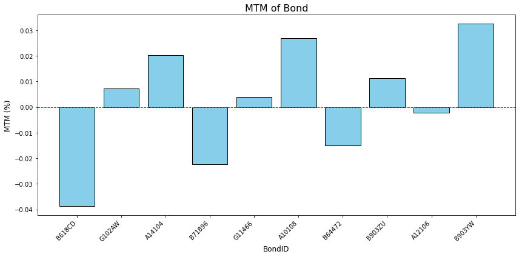

```python
import matplotlib.pyplot as plt

# 設定圖表大小
plt.figure(figsize=(12,6))

# 畫出直條圖 (BondID 在 X 軸，MTM 在 Y 軸)
plt.bar(bond_pos["BondID"], bond_pos["MTM(%)"], color="skyblue", edgecolor="black")

# 標題與標籤
plt.title("MTM of Bond", fontsize=16)
plt.xlabel("BondID", fontsize=12)
plt.ylabel("MTM (%)", fontsize=12)

# 旋轉 X 軸債券代號，避免重疊
plt.xticks(rotation=45, ha="right")

# 畫一條水平的 0 基準線（方便看盈虧正負）
plt.axhline(0, color="red", linestyle="--", linewidth=1)

plt.tight_layout()
plt.show()
```

### DV01 of Bond

DV01為利率變動 1 個bp所造成的損益變動

如果 DV01 < 0，利率上升會造成盈利

```python
class BondDVO1Calculator:
    def __init__(self, df: pd.DataFrame):
        self.df = df
        self.dvo1_by_type = None

    def clean_numeric_columns(self, columns: list):
        """將指定欄位轉為數字，無法轉換的設為 NaN"""
        for col in columns:
            self.df[col] = pd.to_numeric(self.df[col], errors="coerce")

    def calculate_dvo1(self):
        """計算 DVO1 並直接更新到原始 DataFrame"""
        self.df["DVO1"] = (
            self.df["Duration"] *
            self.df["MarketPrice"] *
            0.0001 *
            self.df["Position(Mio)"]
        )
        # 把 NaN 轉 0
        self.df["DVO1"] = self.df["DVO1"].fillna(0)

    def aggregate_by_type(self):
        """按 BondType 聚合 DVO1"""
        self.dvo1_by_type = self.df.groupby("BondType")["DVO1"].sum()
        return self.dvo1_by_type

    def run(self):
        self.clean_numeric_columns(["Duration", "MarketPrice", "Position(Mio)"])
        self.calculate_dvo1()
        return self.aggregate_by_type()


calculator = BondDVO1Calculator(bond_pos)
dvo1_by_type = calculator.run()
```

```python
cols_to_show = ['BondID', 'Issuer','Position(Mio)', 'MTM','DVO1']
html_table = bond_pos[cols_to_show].head(10).to_html(index=False)
display(HTML('<div style="overflow-x:auto">' + html_table + '</div>'))
```

| BondID | Issuer | Position(Mio) | MTM | DVO1 |
| --- | --- | --- | --- | --- |
| B618CD | 台積電 | 6000 | -23512.800 | 93.389952 |
| G102AW | 玉山銀行 | 4500 | 3227.850 | 0.000000 |
| A14104 | 中央銀行 | 12000 | 23900.400 | 561.764986 |
| B71896 | 台灣中油 | 550 | -1197.735 | 13.936950 |
| G11466 | 中信銀行 | 3500 | 1337.000 | 91.449533 |
| A10108 | 中央銀行 | 800 | 2075.520 | 6.354842 |
| B64472 | 鴻海 | 7700 | -11764.060 | 42.592327 |
| B903ZU | 台灣電力 | 25000 | 28257.500 | 970.237623 |
| A12106 | 中央銀行 | 9000 | -1966.500 | 237.919311 |
| B903YW | 台灣電力 | 10000 | 31411.000 | 35.978796 |

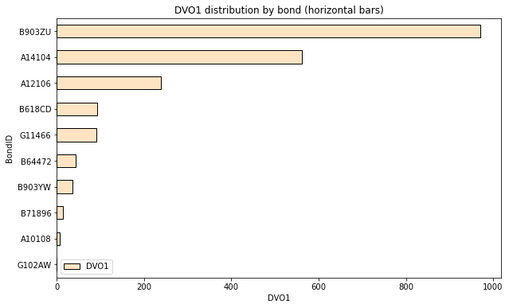

```python
bond_pos.sort_values("DVO1", ascending=True).plot(
    x="BondID", y="DVO1", kind="barh", color="bisque", edgecolor="black", figsize=(10,6)
)
plt.title("DVO1 distribution by bond (horizontal bars)")
plt.xlabel("DVO1")
plt.ylabel("BondID")
plt.show()
```

用水平條形圖（Bar Chart）可以清楚看出各債券的利率風險大小

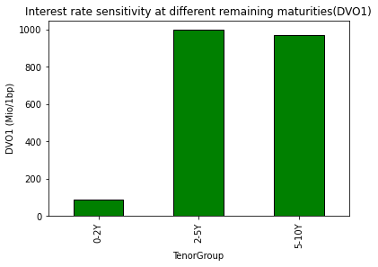

```python
# 先把剩餘年限分類
bond_pos["TenorGroup"] = pd.cut(bond_pos["YearsToMaturity"], bins=[0,2,5,10], labels=["0-2Y","2-5Y","5-10Y"])
dvo1_by_tenor = bond_pos.groupby("TenorGroup")["DVO1"].sum()
dvo1_by_tenor.plot(kind="bar", color="green", edgecolor="black")
plt.title("Interest rate sensitivity at different remaining maturities(DVO1)")
plt.ylabel("DVO1 (Mio/1bp)")
plt.show()
```

DV01 跟Duration正相關，長天期債券利率敏感度高，短天期低。

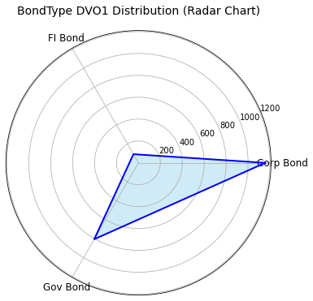

```python
import matplotlib.pyplot as plt
import numpy as np

# 聚合 BondType 的 DVO1
dvo1_by_type = bond_pos.groupby("BondType")["DVO1"].sum()

# 準備資料
labels = dvo1_by_type.index
values = dvo1_by_type.values

# 雷達圖需要首尾相接
angles = np.linspace(0, 2 * np.pi, len(labels), endpoint=False).tolist()
values = np.concatenate((values, [values[0]]))
angles += angles[:1]

# 畫圖
fig, ax = plt.subplots(figsize=(6, 6), subplot_kw=dict(polar=True))

ax.plot(angles, values, color="blue", linewidth=2)
ax.fill(angles, values, color="skyblue", alpha=0.4)

ax.set_xticks(angles[:-1])
ax.set_xticklabels(labels, fontsize=12)

ax.set_title("BondType DVO1 Distribution (Radar Chart)", fontsize=14, pad=20)
plt.show()
```

- 由上圖可知，Corp Bond（公司債） 的 DVO1 最長 → 對利率變動最敏感
- 代表如果利率上升 1bp，Corp Bond 帶來的損益變動最大
- Radar Chart看起來 偏向單邊（Corp Bond 拉很長，FI Bond 很短)
- 表示部位的利率風險比較集中在公司債，而不是平均分散
- 若公司債的 Duration 偏長，可能放大風險。

### 為了驗證公司債的DV01是否為Duration 偏長造成的，我們可以做一些分析：

- DV01 同時取決於部位大小（Position)和存續期間（Duration）
- 如果公司債的 Duration 偏長，在相同 Position 下，它的 DV01 就會比其他債券大，風險更集中

1.首先，把債券分組（BondType） → Corp Bond, Gov Bond, FI Bond

2.計算每類的平均 Duration

3.計算每類的平均 Position

4.對比 Duration 與 DV01 的關係

- 如果公司債的平均 Duration 顯著偏長 → Duration 也是推高 DVO1 的原因之一
- 如果公司債的 Duration 普通，但 Position 特別大 → 代表 DVO1 主要來自 Position

```python
df_group = bond_pos.groupby("BondType").agg(
    Avg_Duration=("Duration", "mean"),
    Total_Position=("Position(Mio)", "sum"),
    Total_DVO1=("DVO1", "sum")
).reset_index()

# 計算單位 Position 的 DVO1 (觀察 Duration 對 DVO1 的影響)
df_group["DVO1_per_Position"] = df_group["Total_DVO1"] / df_group["Total_Position"]

html_table = df_group.head(10).to_html(index=False)
display(HTML('<div style="overflow-x:auto">' + html_table + '</div>'))
```

| BondType | Avg_Duration | Total_Position | Total_DVO1 | DVO1_per_Position |
| --- | --- | --- | --- | --- |
| Corp Bond | 1.798 | 49250 | 1156.135647 | 0.023475 |
| FI Bond | 1.295 | 8000 | 91.449533 | 0.011431 |
| Gov Bond | 2.700 | 21800 | 806.039138 | 0.036974 |

公司債的 DVO1_per_Position 跟其他BondType沒有差很多（甚至比Gov Bond 小），但 Total_Position 較大

→ 代表風險來自於Position，而不是 Duration

### 假設檢定：比較Duration 的「整體分布」是否有顯著差異

H0：公司債的 Duration 與其他債券沒有顯著差異

H1：公司債的 Duration 顯著大於其他債券

因樣本數較少，故採用 **Kruskal-Wallis test**

```python
class KruskalWallisTest:
    def __init__(self, group_data: dict):
        """
        group_data: dict, key為組名，value為資料序列
        例如 {"公司債": corp_dur, "公債": gov_dur, "金融債": fi_dur}
        """
        self.group_data = group_data
        self.h_stat = None
        self.p_value = None

    def run_test(self):
        # 將所有組的資料傳給 kruskal
        self.h_stat, self.p_value = stats.kruskal(*self.group_data.values())

    def report(self):
        group_names = ", ".join(self.group_data.keys())
        print(f"Kruskal-Wallis H-test for {group_names}: H={self.h_stat}, p-value={self.p_value}")


group_data = {
    "公司債": bond_pos[bond_pos["BondType"]=="Corp Bond"]["Duration"],
    "公債": bond_pos[bond_pos["BondType"]=="Gov Bond"]["Duration"],
    "金融債": bond_pos[bond_pos["BondType"]=="FI Bond"]["Duration"]
}

kruskal_test = KruskalWallisTest(group_data)
kruskal_test.run_test()
kruskal_test.report()
```

```
Kruskal-Wallis H-test for 公司債, 公債, 金融債: H=2.021818181818176, p-value=0.36388802186639113
```

Kruskal-Wallis 只能告訴我們「至少有一組不一樣」，但不會說哪兩組不同

因此，再進行**pairwise Mann-Whitney U test**:

```python
class MannWhitneyTest:
    def __init__(self, group1_name, group1_data, group2_name, group2_data):
        self.group1_name = group1_name
        self.group1_data = group1_data
        self.group2_name = group2_name
        self.group2_data = group2_data
        self.u_stat = None
        self.p_val = None

    def run_test(self, alternative='greater'):
        self.u_stat, self.p_val = stats.mannwhitneyu(
            self.group1_data, self.group2_data, alternative=alternative
        )

    def report(self):
        print(f"{self.group1_name} vs {self.group2_name}: U={self.u_stat}, p={self.p_val}")




corp_dur = bond_pos[bond_pos["BondType"] == "Corp Bond"]["Duration"]
gov_dur = bond_pos[bond_pos["BondType"] == "Gov Bond"]["Duration"]
fi_dur  = bond_pos[bond_pos["BondType"] == "FI Bond"]["Duration"]

test1 = MannWhitneyTest("公司債", corp_dur, "公債", gov_dur)
test1.run_test()
test1.report()

test2 = MannWhitneyTest("公司債", corp_dur, "金融債", fi_dur)
test2.run_test()
test2.report()
```

```
公司債 vs 公債: U=4.0, p=0.8749999999999999
公司債 vs 金融債: U=7.0, p=0.2857142857142857
```

**Conclusion**：

分析結果顯示，公司債的總DV01較高，主要受到**較大持倉規模**的影響；然而，在單位部位風險（DVO1_per_Position） 的比較下，債券類型之間的差異並不顯著，Kruskal-Wallis 檢定亦未支持「公司債因 Duration 偏長而放大風險」的假設。 因此，風險放大的主要來源應解釋為部位配置效應，而非債券屬性的內在差異。

### Stress Test:模擬 ±10bp、±50bp、±100bp 的利率變動對部位市值的影響

```python
for bp_change in [-100, -50, -10, 10, 50, 100]:
    mtm_change = bond_pos["DVO1"].sum() * bp_change
    print(f"利率變動 {bp_change} bp → MTM Change: {mtm_change:.2f} Mio")
```

```
利率變動 -100 bp → MTM Change: -205362.43 Mio
利率變動 -50 bp → MTM Change: -102681.22 Mio
利率變動 -10 bp → MTM Change: -20536.24 Mio
利率變動 10 bp → MTM Change: 20536.24 Mio
利率變動 50 bp → MTM Change: 102681.22 Mio
利率變動 100 bp → MTM Change: 205362.43 Mio
```

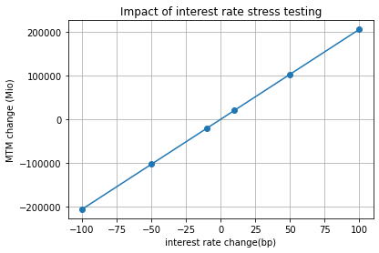

```python
bp_changes = [-100, -50, -10, 10, 50, 100]
mtm_changes = [bond_pos["DVO1"].sum() * bp for bp in bp_changes]

plt.plot(bp_changes, mtm_changes, marker='o')
plt.xlabel("interest rate change(bp)")
plt.ylabel("MTM change (Mio)")
plt.title("Impact of interest rate stress testing")
plt.grid(True)
plt.show()
```

**Conclusion**

1.當利率變動從 -100bp 到 +100bp 時，MTM 變動呈現近似線性對稱關係，市值變動與利率變動幅度成比例

3.在極端情境（±100bp）下，部位市值可能單邊變動 20 萬 Mio 以上，風險承受能力可能不足

4.應該進一步檢視久期部位配置，並考慮採取避險策略（例如 IRS、期貨），以降低對利率單邊波動的曝險